# R Bootcamp Analysis - Agora DarkNet Activity

Konstantinos Lessis, Pascal Himmelberger

07/09/2020

# Data Load

```r
# Loading the CSV dataset from kaggle.com: https://www.kaggle.com/philipjames11/dark-net-marketplace-drug-data-agora-20142015
agora.source <- read.csv2('G:/Dev/DataScience/RBootcamp/Group_Work/source/Agora.csv', sep=',')

# overview of dataset and available variables
str(agora.source)
```

```
'data.frame':   109689 obs. of  9 variables:
 $ Vendor          : chr  "CheapPayTV" "CheapPayTV" "KryptykOG" "cyberzen" ...
 $ Category        : chr  "Services/Hacking" "Services/Hacking" "Services/Hacking" "Services/Hacking" ...
 $ Item            : chr  "12 Month HuluPlus gift Code" "Pay TV Sky UK  Sky Germany HD TV  and much more.. CCcam Service 12 Months" "OFFICIAL Account Creator Extreme 4.2" "VPN > TOR > SOCK TUTORIAL" ...
 $ Item.Description: chr  "12-Month HuluPlus Codes for $25. They are worth $95. They will be sent to you within 1 day. Most within a hour or two" "Hi we offer a World Wide CCcam  Service for Enigma 2 devices! 12 Months 75$   Following Satellites are availabl"| __truncated__ "Tagged Submission Fix Be…
 $ Price           : chr  "0.05027025666666667 BTC" "0.152419585 BTC" "0.007000000000000005 BTC" "0.019016783532494728 BTC" ...
 $ Origin          : chr  "Torland" "Torland" "Torland" "" ...
 $ Destination     : chr  "" "" "" "" ...
 $ Rating          : chr  "4.96/5" "4.96/5" "4.93/5" "4.89/5" ...
 $ Remarks         : chr  "" "" "" "" ...
```

The *agora* dataset includes 100’000+ observations with 9 distinct attributes. As the output above shows, R categorized all variables as strings. Looking at the available values, it is clear that some of those attributes are categorical attributes or *factors* rather than pure string attributes. We will implement the attribute data type transformation in the next step.

Before we start converting attributes into their correct data type, we must perform some cleanup due to some corrupted lines in the CSV file:

```r
# remove invalid lines (shifted values) where BTC prices are listed in the [Category] field
agora.cleaned <- agora.source[  !agora.source$Category %in% c('0.12780125125 BTC','0.1905617980645162 BTC'), ]
# remove invalid lines (shifted values) where 'kind hearts' appears in the [Category] Field
agora.cleaned <- agora.cleaned[grep('.*kind hearts.*',
                                    agora.source$Category,
                                    perl = TRUE,
                                    ignore.case = TRUE,
                                    invert = TRUE)
                                , ]
# while the specified grep pattern seems correct, not all invalid values seem to be removed. 1 specific line was not matched, see below
agora.cleaned <- agora.cleaned[agora.cleaned$Category != 'the Body Bags  shotty  and mag To: Kind Hearts and Gentle People', ]
# unique(agora.cleaned$Category)
```

The source CSV structure seems to contain corrupted lines due to invalid EOL characters, messing up the content of some fields. This was evident while looking at the *Category* attribute, which showed the following values that are not supposed to be listed in the *Category* field:

- ‘0.12780125125 BTC’
- ‘0.1905617980645162 BTC’
- ‘home of the Body Bags shotty and mag Kind Hearts and Gentle People’
- ‘the Body Bags shotty and mag To: Kind Hearts and Gentle People’

# Exploratory Analysis of *Agora* Data

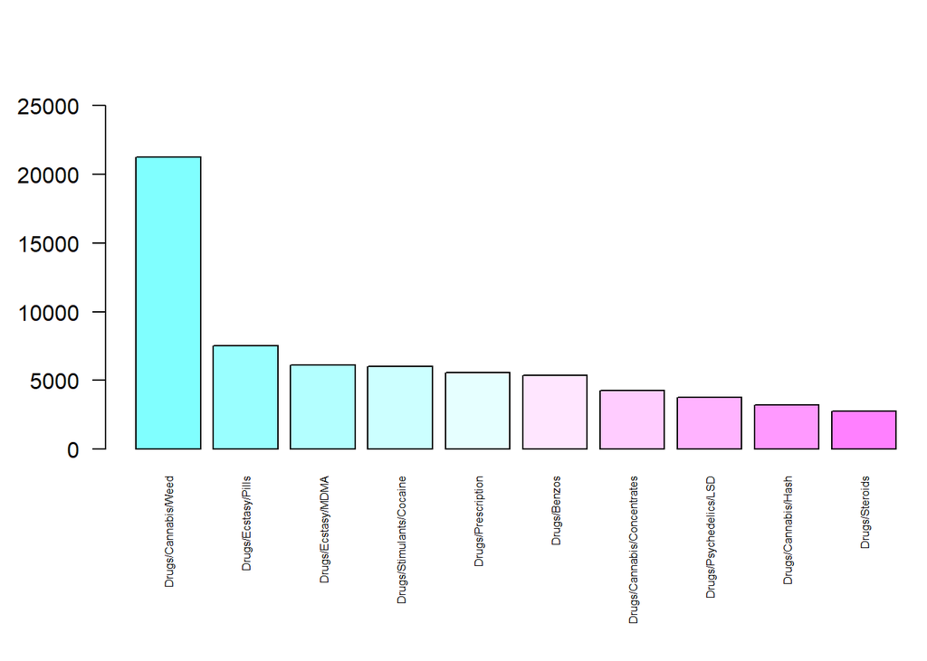

```r
# top categories
# agora.percategory <- data.frame(category = unique(agora.cleaned$Category, count = aggregate))
agora.aggregated <- aggregate.data.frame(agora.cleaned, by=list(agora.cleaned$Category), FUN='length')
# Top 10 number of items per category
agora.counts <- agora.aggregated[order(-agora.aggregated$Vendor), ][1:10, 1:2]

par(oma=c(4,2,2,0), mar=c(4,2,2,0))
barplot(agora.counts$Vendor,
        names.arg = agora.counts$Group.1,
        ylim = c(0, 25000),
        cex.names = 0.5,
        las = 2,
        col=cm.colors(10)
)
```